# Exercise 3 of “Big Data Analytics” (Winter Semester 2020/21)

# Task 2: Decision Trees

To make our code more generic, we define variables for the dataset and the prediction target. This allows swapping the dataset if we wanted.

```r
dataset <- iris
target <- "Species"
```

As a reminder, here are the plots of all attributes’ distributions, grouped by `Species`:

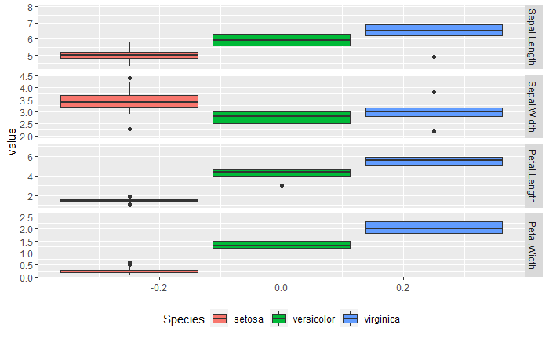

```r
library(ggplot2)
dataMelted <- reshape2::melt(data = dataset, measure.vars = setdiff(colnames(dataset), target))
ggplot(data = dataMelted) +
  geom_boxplot(mapping = aes_string(y = "value", fill = target)) +
  facet_grid(variable ~ ., scales = "free_y") +
  theme(legend.position = "bottom")
```

## a) Train-Test-Split

We create a train-test split by sampling 70% of the row indices for training and using the rest for testing:

```r
set.seed(25)
trainIdx <- sort(sample(1:nrow(dataset), size = round(0.7 * nrow(dataset)), replace = FALSE))
testIdx <- c(1:nrow(dataset))[-trainIdx] # use all indices except trainIdx
trainData <- dataset[trainIdx, ]
testData <- dataset[testIdx, ]
```

`set.seed()` ensures reproducibility by initializing the random number generator.

Why do we split at all? Well, we want to check whether our model can generalize or it just memorizes the training data, i.e., overfits. Some decision tree implementations simply split the data until all leaves only contain one class, even if they contain only one data object. This can result in overly specific rules. In `rpart`, you can use the parameter `control` to adjust the learning behavior.

## b) Training

Training basically is a one-liner:

```r
library(rpart)
predictionFormula <- as.formula(paste(target, "~ ."))
rpartModel <- rpart(predictionFormula, data = trainData)
```

The formula `Species ~ .` means that `Species` should be predicted from all other features. You could also list the features like `Species ~ Sepal.Length + Sepal.Width + Petal.Length + Petal.Width`. Formulas are special objects in R, belonging to class `formula`. In more complicated formulas, you can also include interaction terms between features.

## c) Inspecting the Model

By printing the model, we get a textual representation of the decision tree:

```r
print(rpartModel)
```

```
n= 105

node), split, n, loss, yval, (yprob)
      * denotes terminal node

1) root 105 67 virginica (0.32380952 0.31428571 0.36190476)
  2) Petal.Length< 2.45 34  0 setosa (1.00000000 0.00000000 0.00000000) *
  3) Petal.Length>=2.45 71 33 virginica (0.00000000 0.46478873 0.53521127)
    6) Petal.Length< 5.05 36  3 versicolor (0.00000000 0.91666667 0.08333333) *
    7) Petal.Length>=5.05 35  0 virginica (0.00000000 0.00000000 1.00000000) *
```

We do not only see the splits, but also the number of data objects and the class probabilities in each node. Nevertheless, a graphical representation is nicer:

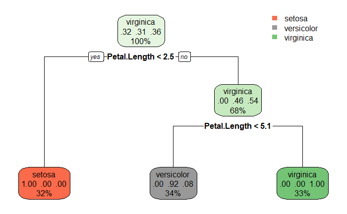

```r
library(rpart.plot)
rpart.plot(rpartModel)
```

Going back to the entropy task and the plot task, we already saw that `Petal.Length` is good for separating classes. Note that the `rpart` tree uses split points between attribute values, therefore choosing 2.5 in the first split (in the middle of the highest `Petal.Length` of `setosa` and the lowest `Petal.Length` of `versicolor`), while our split entropy algorithm considered the attribute values themselves, therefore proposing a split at 1.9 (the highest `Petal.Length` of `setosa`). You can change the splitting algorithm in the `rpart()` call. For categorical data, it uses Gini impurity by default. While this criterion has a different formula than entropy, results seem similar here.

Can we also use the default plot functionality of R?

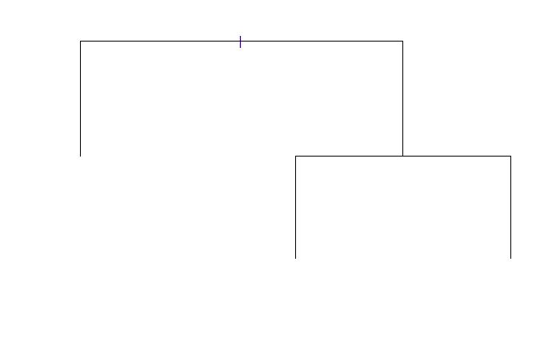

```r
plot(rpartModel)
```

Seems to lack some information. Actually, we have to add labels manually:

```r
par(xpd = TRUE) # clip plot to figure region
plot(rpartModel, compress = TRUE)
text(rpartModel, use.n = TRUE) # "use.n" = add number of objects in leaf
```

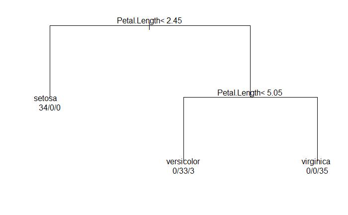

```r
par(xpd = FALSE)
```

Still not something you wanted to show your boss, though.

## d) Evaluation

As we already saw above, the leaf nodes are quite pure, resulting in a high training accuracy:

```r
prediction <- predict(rpartModel, newdata = trainData, type = "class")
table(prediction, trainData[[target]], dnn = c("prediction", "actual"))
```

```
            actual
prediction   setosa versicolor virginica
  setosa         34          0         0
  versicolor      0         33         3
  virginica       0          0        35
```

```r
cat("Accuracy:", sum(prediction == trainData[[target]]) / nrow(trainData))
```

```
Accuracy: 0.9714286
```

We get worse, but still acceptable results for the test data:

```r
prediction <- predict(rpartModel, newdata = testData, type = "class")
table(prediction, testData[[target]], dnn = c("prediction", "actual"))
```

```
            actual
prediction   setosa versicolor virginica
  setosa         16          0         0
  versicolor      0         16         6
  virginica       0          1         6
```

```r
cat("Accuracy:", sum(prediction == testData[[target]]) / nrow(testData))
```

```
Accuracy: 0.8444444
```

In particular, there seem to be more `virginica` flowers predicted to be `versicolor`. Let’s have a look how `Petal.Length`, the split attribute, is distributed for `virginica` in train and test:

```r
summary(trainData[trainData[[target]] == "virginica", "Petal.Length"])
```

```
   Min. 1st Qu.  Median    Mean 3rd Qu.    Max.
  4.500   5.225   5.600   5.595   5.875   6.700
```

```r
summary(testData[testData[[target]] == "virginica", "Petal.Length"])
```

```
   Min. 1st Qu.  Median    Mean 3rd Qu.    Max.
  4.900   4.975   5.050   5.417   5.800   6.900
```

The median and mean are lower in the test data than in the training data. Thus, there are some `virginica` objects in the test data having a `Petal.Length` which is considered to belong to `versicolor` in the training data. In general, training data should be representative for the true distribution of features and class labels. However, for a small sample, this is hard to achieve, and we didn’t take care of it here. Furthermore, in real-world scenarios, after training a model, the value distribution of newly collected data objects might change due to various reasons.

## e) Alternative Packages

### `party`

```r
library(party)
ctreeModel <- ctree(predictionFormula, data = trainData)
print(ctreeModel) # rules of the tree
```

```
     Conditional inference tree with 4 terminal nodes

Response:  Species
Inputs:  Sepal.Length, Sepal.Width, Petal.Length, Petal.Width
Number of observations:  105

1) Petal.Length <= 1.9; criterion = 1, statistic = 98.391
  2)*  weights = 34
1) Petal.Length > 1.9
  3) Petal.Width <= 1.5; criterion = 1, statistic = 50.867
    4) Petal.Length <= 4.4; criterion = 0.987, statistic = 8.616
      5)*  weights = 24
    4) Petal.Length > 4.4
      6)*  weights = 8
  3) Petal.Width > 1.5
    7)*  weights = 39
```

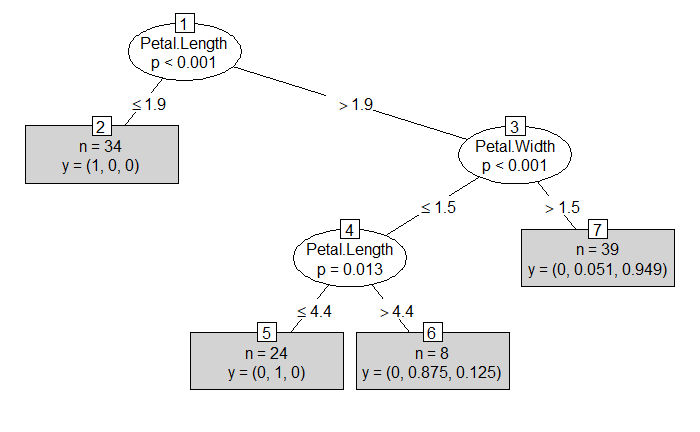

```r
plot(ctreeModel, type = "simple")
```

```r
prediction <- predict(ctreeModel, newdata = testData)
table(prediction, testData[[target]], dnn = c("prediction", "actual"))
```

```
            actual
prediction   setosa versicolor virginica
  setosa         16          0         0
  versicolor      0         14         2
  virginica       0          3        10
```

```r
cat("Accuracy:", sum(prediction == testData[[target]]) / nrow(testData))
```

```
Accuracy: 0.8888889
```

The API of the `party` package is equally simple. We also get a built-in textual and graphical representation. The prediction function is called `predict()` in most ML-related R packages, and using a formula to specify the feature-target relationship is also common. However, there is no common super-class which would enforce such an interface.

### `C50`

```r
library(C50)
c50Model <- C5.0(predictionFormula, data = trainData)
summary(c50Model)
```

```
Call:
C5.0.formula(formula = predictionFormula, data = trainData)


C5.0 [Release 2.07 GPL Edition]     Sat Dec 12 11:00:44 2020
-------------------------------

Class specified by attribute `outcome'

Read 105 cases (5 attributes) from undefined.data

Decision tree:

Petal.Length <= 1.9: setosa (34)
Petal.Length > 1.9:
:...Petal.Length > 5: virginica (35)
    Petal.Length <= 5:
    :...Petal.Width <= 1.6: versicolor (31)
        Petal.Width > 1.6:
        :...Sepal.Width <= 2.9: virginica (2)
            Sepal.Width > 2.9: versicolor (3/1)


Evaluation on training data (105 cases):

        Decision Tree
      ----------------
      Size      Errors

         5    1( 1.0%)   <<


       (a)   (b)   (c)    <-classified as
      ----  ----  ----
        34                (a): class setosa
              33          (b): class versicolor
               1    37    (c): class virginica


    Attribute usage:

    100.00% Petal.Length
     34.29% Petal.Width
      4.76% Sepal.Width


Time: 0.0 secs
```

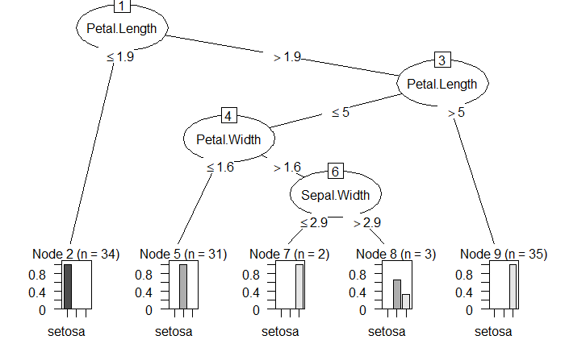

```r
plot(c50Model)
```

```r
prediction <- predict(c50Model, newdata = testData)
table(prediction, testData[[target]], dnn = c("prediction", "actual"))
```

```
            actual
prediction   setosa versicolor virginica
  setosa         16          0         0
  versicolor      0         16         2
  virginica       0          1        10
```

```r
cat("Accuracy:", sum(prediction == testData[[target]]) / nrow(testData))
```

```
Accuracy: 0.9333333
```

Again, a similar API, but different default hyper-parameters and a different splitting procedure, resulting in a different tree structure.